# Analysis: Machine Learning - ReqAmt - Outliers

## Introduction

This script uses requested FEMA funds as the outcome of interest and fits the following models to the analysis data:

- Null
- Decision Tree
- Random Forest
- Elastic Net
- LASSO

It compares the models, and then finally fits the “best” model to the test data. It also removes the clear outliers in the original analysis where the log(ReqAmt) was less than zero.

Follow the previous processing and analysis markdowns to generate the analysis data used here.

Each model will follow this process:

1. Model Specification
2. Workflow Definition
3. Tuning Grid Specification
4. Tuning Using Cross-Validation and the tune_grid() function
5. Identify Best Model
6. Model Evaluation

## Required Packages

The following R packages are required for this script:

- here: for data loading/saving
- tidyverse: for data management
- tidymodels: for data modeling
- skimr: for variable summaries
- spatialsample: for spatial cross-validation
- broom.mixed: for converting bayesian models to tidy tibbles
- rpart.plot: for visualizing a decision tree
- vip: for variable importance plots
- glmnet: for lasso models
- doParallel: for parallel backend for tuning processes
- ranger: for random forest models
- baguette: for bagged decision tree
- viridis: for a consistent color scheme in figures

## Load Data

Load the ReqAmt analysis data from the `processed_data` folder in the project file.

```r
#path to data
#note the use of the here() package and not absolute paths
data_location <- here::here("data","processed_data","analysisdata-RA.rds")

#load data.
analysisdata <- readRDS(data_location)

#summary of data using skimr package
skimr::skim(analysisdata)
```

Data summary

| Name | analysisdata |
| --- | --- |
| Number of rows | 326 |
| Number of columns | 23 |
| _______________________ |  |
| Column type frequency: |  |
| character | 5 |
| factor | 4 |
| numeric | 14 |
| ________________________ |  |
| Group variables | None |

**Variable type: character**

| skim_variable | n_missing | complete_rate | min | max | empty | n_unique | whitespace |
| --- | --- | --- | --- | --- | --- | --- | --- |
| state | 0 | 1 | 2 | 2 | 0 | 51 | 0 |
| FEMARegion | 0 | 1 | 8 | 11 | 0 | 10 | 0 |
| declarationType | 0 | 1 | 2 | 2 | 0 | 2 | 0 |
| declarationTitle | 0 | 1 | 8 | 81 | 0 | 100 | 0 |
| incidentType | 0 | 1 | 4 | 16 | 0 | 9 | 0 |

**Variable type: factor**

| skim_variable | n_missing | complete_rate | ordered | n_unique | top_counts |
| --- | --- | --- | --- | --- | --- |
| IncidentMonth | 0 | 1 | TRUE | 12 | Jan: 71, Oct: 41, Aug: 32, Sep: 31 |
| IH | 0 | 1 | FALSE | 2 | Not: 163, Awa: 163 |
| PA | 0 | 1 | FALSE | 2 | Awa: 318, Not: 8 |
| HM | 0 | 1 | FALSE | 2 | Awa: 260, Not: 66 |

**Variable type: numeric**

| skim_variable | n_missing | complete_rate | mean | sd | p0 | p25 | p50 | p75 | p100 | hist |
| --- | --- | --- | --- | --- | --- | --- | --- | --- | --- | --- |
| latitude | 0 | 1 | 37.82 | 7.19 | 18.22 | 33.84 | 37.96 | 43.19 | 63.59 | ▁▆▇▁▁ |
| longitude | 0 | 1 | -93.67 | 18.41 | -155.67 | -99.90 | -91.83 | -81.16 | -66.59 | ▁▁▂▇▇ |
| Population | 0 | 1 | 9313643.01 | 10333562.39 | 576851.00 | 3011524.00 | 5706494.00 | 10439388.00 | 39538223.00 | ▇▂▁▁▁ |
| Counties | 0 | 1 | 75.26 | 53.47 | 1.00 | 46.00 | 67.00 | 88.00 | 254.00 | ▃▇▁▁▁ |
| disasterNumber | 0 | 1 | 4157.55 | 392.84 | 3346.00 | 4080.25 | 4276.50 | 4457.25 | 4619.00 | ▅▁▂▇▇ |
| IncidentYear | 0 | 1 | 2016.97 | 2.89 | 2012.00 | 2015.00 | 2017.00 | 2020.00 | 2021.00 | ▅▃▅▅▇ |
| IncidentDuration | 0 | 1 | 135.66 | 250.30 | 0.00 | 5.00 | 14.00 | 46.25 | 660.00 | ▇▁▁▁▂ |
| ResponseDays | 0 | 1 | 1404.07 | 898.44 | 70.04 | 660.00 | 1178.54 | 2066.51 | 3588.00 | ▇▅▅▃▂ |
| IH_pct | 0 | 1 | 0.34 | 1.59 | 0.00 | 0.00 | 0.00 | 0.24 | 27.69 | ▇▁▁▁▁ |
| PA_pct | 0 | 1 | 0.59 | 1.56 | 0.00 | 0.14 | 0.36 | 1.00 | 27.31 | ▇▁▁▁▁ |
| HM_pct | 0 | 1 | 0.48 | 1.56 | 0.00 | 0.04 | 0.21 | 0.60 | 27.25 | ▇▁▁▁▁ |
| TotalAgencies | 0 | 1 | 6.23 | 7.03 | 1.00 | 2.00 | 3.00 | 8.00 | 55.00 | ▇▂▁▁▁ |
| FEMACSAvg | 0 | 1 | 0.96 | 0.06 | 0.68 | 0.95 | 1.00 | 1.00 | 1.00 | ▁▁▁▂▇ |
| ReqAmt | 0 | 1 | 40601806.50 | 255138972.55 | 0.00 | 51024.33 | 420063.94 | 4751605.15 | 4388540486.39 | ▇▁▁▁▁ |

## Data Setup

We will specify the following parameters:

```r
#log transform ReqAmt
analysisdata$logReqAmt <- log(analysisdata$ReqAmt)

#drop unnecessary variables
req_data_2 <- analysisdata %>%
              dplyr::select(-c(ReqAmt, disasterNumber, declarationTitle))

#specify all character variables as factors and clean variable names
req_data_1 <- req_data_2 %>%
                janitor::clean_names() %>%
                dplyr::mutate_if(is.character, factor)

#remove outliers (rows that have a -log(reqamt))
req_data <- req_data_1 %>%
              dplyr::filter(log_req_amt > 0)

#set random seed
set.seed(123)

#split dataset into 66.6% training, 33.3% testing
#use incidentType as stratification
req_data_split <- rsample::initial_split(req_data, prop = 2/3)

#create dataframes for the two sets:
req_train_data <- rsample::training(req_data_split)
req_test_data <- rsample::testing(req_data_split)

#5-fold spatial cross validation
req_folds_spatial <- spatialsample::spatial_clustering_cv(req_train_data,
                                                          coords = c(latitude, longitude),
                                                          v = 5)

#create recipe that codes categorical variables as dummy variables
RA_rec <- recipes::recipe(log_req_amt ~ ., data = req_train_data) %>%
          recipes::step_unknown(state, new_level = "unknown state") %>%
          recipes::step_dummy(all_nominal_predictors())
```

## Null Model

Determine the performance of a null model (i.e. one with no predictors) and compute the RMSE for both training and test data.

```r
#create null model
null_mod <- parsnip::null_model() %>%
            parsnip::set_engine("parsnip") %>%
            parsnip::set_mode("regression")

#add recipe and model into workflow
null_wflow <- workflows::workflow() %>%
              workflows::add_recipe(RA_rec) %>%
              workflows::add_model(null_mod)

#"fit" model to training data
req_null_train <- null_wflow %>%
                  parsnip::fit(data = req_train_data)

#summary of null model with training data to get mean (which in this case is the RMSE)
req_null_train_sum <- broom.mixed::tidy(req_null_train)
req_null_train_sum
```

```
## # A tibble: 1 x 1
##   value
##   <dbl>
## 1  13.2
```

```r
#RMSE for training data for formatting later
req_null_RMSE_train <- tibble::tibble(
                          rmse = rmse_vec(truth = req_train_data$log_req_amt,
                                              estimate = rep(mean(req_train_data$log_req_amt), nrow(req_train_data))),
                          SE = 0,
                          model = "Null - Train")

#"fit" model to test data
req_null_test <- null_wflow %>%
                  parsnip::fit(data = req_test_data)

#summary of null model with test data to get mean (which in this case is the RMSE)
req_null_test_sum <- broom.mixed::tidy(req_null_test)
req_null_test_sum
```

```
## # A tibble: 1 x 1
##   value
##   <dbl>
## 1  13.4
```

```r
#RMSE for testing data for formatting later
req_null_RMSE_test <- tibble::tibble(
                          rmse = rmse_vec(truth = req_test_data$log_req_amt,
                                              estimate = rep(mean(req_test_data$log_req_amt), nrow(req_test_data))),
                          SE = 0,
                          model = "Null - Test")
```

## Decision Tree

### 1. Model Specification

```r
#run parallels to determine number of cores
cores <- parallel::detectCores() - 1
cores
```

```
## [1] 19
```

```r
cl <- makeCluster(cores)

registerDoParallel(cl)

#define the tree model
tree_mod <-
  parsnip::decision_tree(cost_complexity = tune(),
                         tree_depth = tune(),
                         min_n = tune()) %>%
  parsnip::set_engine("rpart") %>%
  parsnip::set_mode("regression")
```

### 2. Workflow Definition

```r
#define workflow for tree
tree_wflow <- workflows::workflow() %>%
               workflows::add_model(tree_mod) %>%
               workflows::add_recipe(RA_rec)
```

### 3. Tuning Grid Specification

```r
#tuning grid specification
tree_grid <- dials::grid_regular(cost_complexity(),
                                 tree_depth(),
                                 min_n(),
                                 levels = 5)

#tree depth
tree_grid %>%
  dplyr::count(tree_depth)
```

```
## # A tibble: 5 x 2
##   tree_depth     n
##        <int> <int>
## 1          1    25
## 2          4    25
## 3          8    25
## 4         11    25
## 5         15    25
```

### 4. Tuning Using Cross-Validation and the `tune_grid()` function

```r
#tune the model with previously specified cross-validation and RMSE as target metric
tree_res <- tree_wflow %>%
                tune::tune_grid(resamples = req_folds_spatial,
                                grid = tree_grid,
                                control = control_grid(verbose = TRUE),
                                metrics = yardstick::metric_set(rmse))

#collect metrics
tree_res %>% workflowsets::collect_metrics()
```

```
## # A tibble: 125 x 9
##    cost_complexity tree_depth min_n .metric .estimator  mean     n std_err
##              <dbl>      <int> <int> <chr>   <chr>      <dbl> <int>   <dbl>
##  1    0.0000000001          1     2 rmse    standard    2.68     5   0.181
##  2    0.0000000178          1     2 rmse    standard    2.68     5   0.181
##  3    0.00000316            1     2 rmse    standard    2.68     5   0.181
##  4    0.000562              1     2 rmse    standard    2.68     5   0.181
##  5    0.1                   1     2 rmse    standard    2.68     5   0.181
##  6    0.0000000001          4     2 rmse    standard    2.65     5   0.179
##  7    0.0000000178          4     2 rmse    standard    2.65     5   0.179
##  8    0.00000316            4     2 rmse    standard    2.65     5   0.179
##  9    0.000562              4     2 rmse    standard    2.64     5   0.175
## 10    0.1                   4     2 rmse    standard    2.69     5   0.193
## # ... with 115 more rows, and 1 more variable: .config <chr>
```

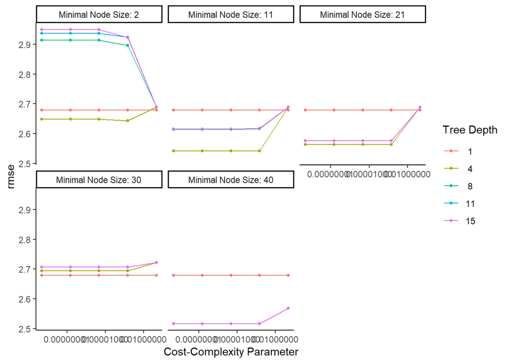

```r
#default visualization
DT_auto_plot <- tree_res %>% autoplot()
DT_auto_plot
```

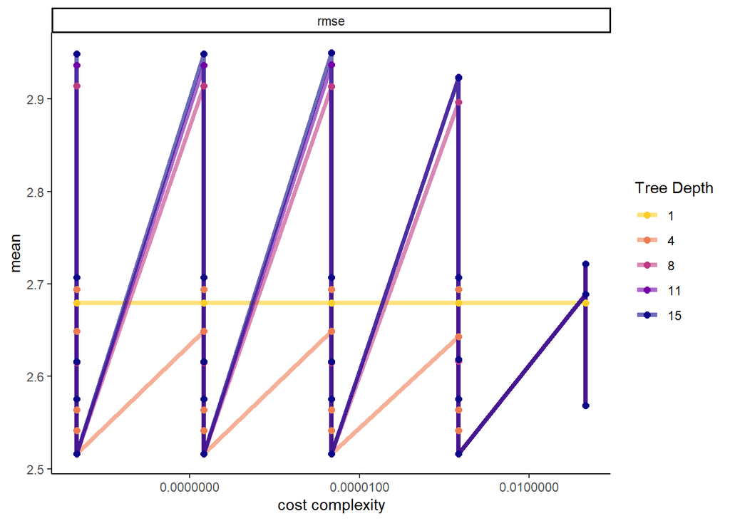

```r
#save file
DT_auto_fig_file = here("results","DT-auto-plot-outlier.png")
ggsave(filename = DT_auto_fig_file, plot = DT_auto_plot)
#more detailed plot
DT_detail_plot <- tree_res %>%
                    workflowsets::collect_metrics() %>%
                    dplyr::mutate(tree_depth = factor(tree_depth)) %>%
                    ggplot2::ggplot(aes(cost_complexity, mean, color = tree_depth)) +
                             geom_line(size = 1.5, alpha = 0.6) +
                             geom_point(size = 2) +
                             facet_wrap(~ .metric, scales = "free") +
                             scale_x_log10(labels = scales::label_number()) +
                             scale_color_viridis_d(option = "plasma", begin = 0.9, end = 0) +
                             labs(x = "cost complexity",
                                  y = "mean",
                                  color = "Tree Depth")
DT_detail_plot
```

```r
#save file
DT_det_fig_file = here("results","DT-det-plot-outlier.png")
ggsave(filename = DT_det_fig_file, plot = DT_detail_plot)
```

### 5. Identify Best Model

```r
#select the tree model with the lowest rmse
tree_lowest_rmse <- tree_res %>%
                        tune::select_best("rmse")

#finalize the workflow by using the selected DT model
best_tree_wflow <- tree_wflow %>%
                      tune::finalize_workflow(tree_lowest_rmse)
best_tree_wflow
```

```
## == Workflow ====================================================================
## Preprocessor: Recipe
## Model: decision_tree()
##
## -- Preprocessor ----------------------------------------------------------------
## 2 Recipe Steps
##
## * step_unknown()
## * step_dummy()
##
## -- Model -----------------------------------------------------------------------
## Decision Tree Model Specification (regression)
##
## Main Arguments:
##   cost_complexity = 0.0000000001
##   tree_depth = 4
##   min_n = 40
##
## Computational engine: rpart
```

```r
#one last fit on the training data
best_tree_fit <- best_tree_wflow %>%
                    parsnip::fit(data = req_train_data)
```

### 6. Model evaluation

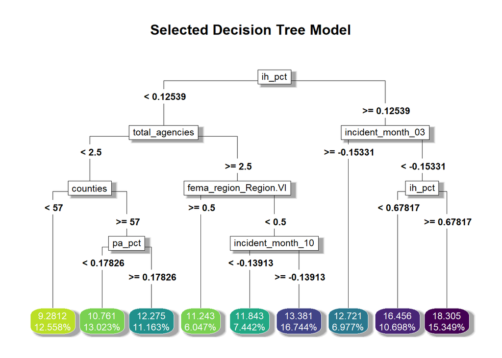

```r
#plot the tree
rpart.plot::rpart.plot(x = workflowsets::extract_fit_parsnip(best_tree_fit)$fit,
                                                     roundint = F,
                                                     type = 5,
                                                     digits = 5,
                                                     main = "Selected Decision Tree Model",
                                                     box.palette = viridis::viridis(10, option = "D", begin = 0.9, end = 0),
                                                     shadow.col = "grey65",
                                                     col = "grey99")
```

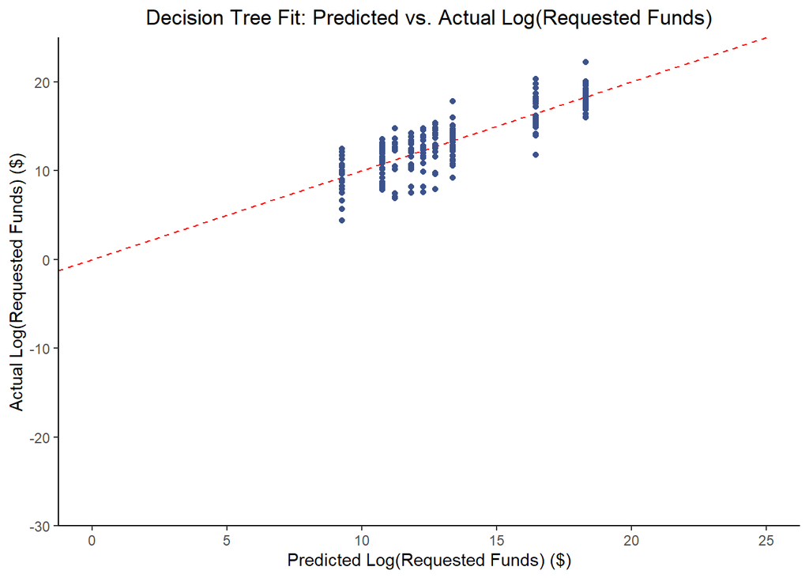

```r
#save manually as "DT-plot-outlier.png" -- ggsave throws an error


#find predictions and intervals
tree_resid <- best_tree_fit %>%
                  broom.mixed::augment(new_data = req_train_data) %>%
                  dplyr::select(.pred, log_req_amt) %>%
                  dplyr::mutate(.resid = .pred - log_req_amt)

#plot model predictions from tuned model versus actual outcomes
#geom_abline draws a 45 degree line, along which the results should fall
DT_pred_act <- ggplot2::ggplot(tree_resid, aes(x = .pred, y = log_req_amt)) +
                        geom_abline(slope = 1, intercept = 0, color = "red", lty = 2) +
                        geom_point(color = "#3b528b") +
                        scale_y_continuous(expand = c(0,0),
                                           limits = c(-30, 25)) +
                        scale_x_continuous(limits = c(0, 25)) +
                        labs(title = "Decision Tree Fit: Predicted vs. Actual Log(Requested Funds)",
                              x = "Predicted Log(Requested Funds) ($)",
                              y = "Actual Log(Requested Funds) ($)")
DT_pred_act
```

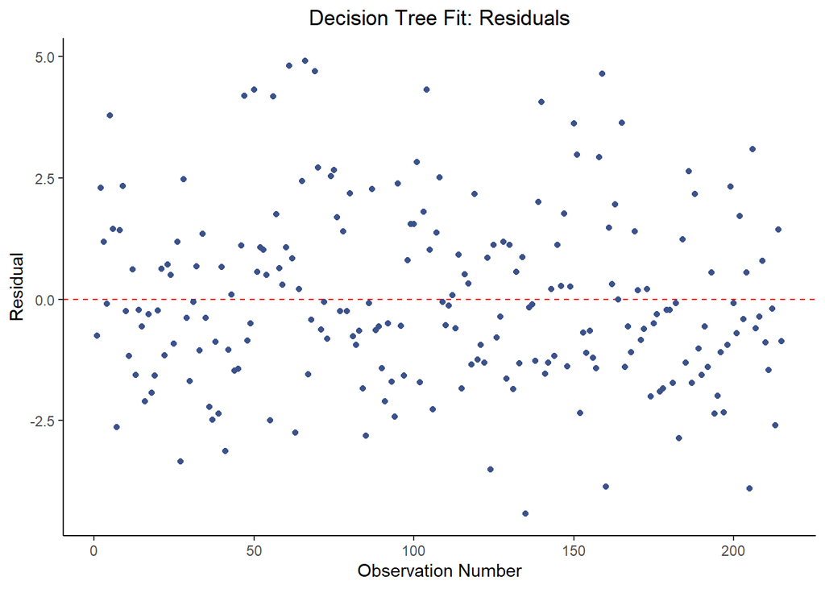

```r
#save file
DT_pred_act_file = here("results","DT-pred-act-outlier.png")
ggsave(filename = DT_pred_act_file, plot = DT_pred_act)
#plot model with residuals
#the geom_hline plots a straight horizontal line along which the results should fall
DT_resid <- ggplot2::ggplot(tree_resid, aes(x = as.numeric(row.names(tree_resid)), y = .resid))+
                     geom_hline(yintercept = 0, color = "red", lty = 2) +
                     geom_point(color = "#3b528b") +
                     labs(title = "Decision Tree Fit: Residuals",
                          x = "Observation Number",
                          y = "Residual")
DT_resid
```

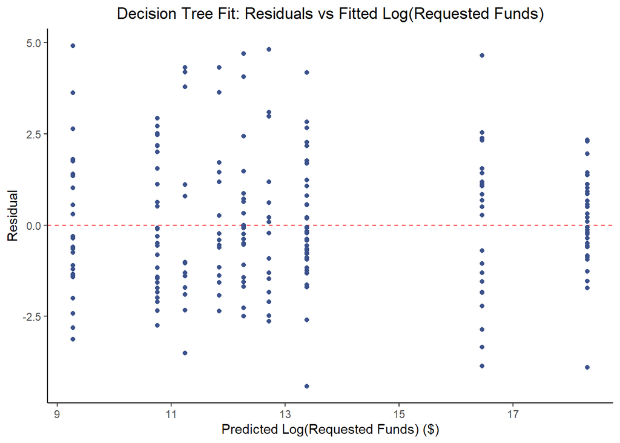

```r
#save file
DT_resid_file = here("results","DT-resid-outlier.png")
ggsave(filename = DT_resid_file, plot = DT_resid)
#plot model fit vs residuals
#the geom_hline plots a straight horizontal line along which the results fall
DT_pred_resid <- ggplot2::ggplot(tree_resid, aes(x = .pred, y = .resid))+
                          geom_hline(yintercept = 0, color = "red", lty = 2) +
                          geom_point(color = "#3b528b") +
                          labs(title = "Decision Tree Fit: Residuals vs Fitted Log(Requested Funds)",
                                x = "Predicted Log(Requested Funds) ($)",
                                y = "Residual")
DT_pred_resid
```

```r
#save file
DT_pred_resid_file = here("results","DT-pred-resid-outlier.png")
ggsave(filename = DT_pred_resid_file, plot = DT_pred_resid)
#print model performance
#print 10 best performing hyperparameter sets
tree_res %>%
  tune::show_best(n = 10) %>%
  dplyr::select(rmse = mean, std_err, cost_complexity) %>%
  dplyr::mutate(rmse = round(rmse, 3),
                std_err = round(std_err, 4),
                cost_complexity = scales::scientific(cost_complexity))
```

```
## # A tibble: 10 x 3
##     rmse std_err cost_complexity
##    <dbl>   <dbl> <chr>
##  1  2.52   0.099 1.00e-10
##  2  2.52   0.099 1.78e-08
##  3  2.52   0.099 3.16e-06
##  4  2.52   0.099 5.62e-04
##  5  2.52   0.099 1.00e-10
##  6  2.52   0.099 1.78e-08
##  7  2.52   0.099 3.16e-06
##  8  2.52   0.099 5.62e-04
##  9  2.52   0.099 1.00e-10
## 10  2.52   0.099 1.78e-08
```

```r
#print the best model performance
tree_performance <- tree_res %>% tune::show_best(n = 1)
print(tree_performance)
```

```
## # A tibble: 1 x 9
##   cost_complexity tree_depth min_n .metric .estimator  mean     n std_err
##             <dbl>      <int> <int> <chr>   <chr>      <dbl> <int>   <dbl>
## 1    0.0000000001          4    40 rmse    standard    2.52     5  0.0990
## # ... with 1 more variable: .config <chr>
```

```r
#compare model performance to null model
tree_RMSE <- tree_res %>%
                tune::show_best(n = 1) %>%
                dplyr::transmute(
                  rmse = round(mean, 3),
                  SE = round(std_err, 4),
                  model = "Tree") %>%
               dplyr::bind_rows(req_null_RMSE_train)
tree_RMSE
```

```
## # A tibble: 2 x 3
##    rmse    SE model
##   <dbl> <dbl> <chr>
## 1  2.52 0.099 Tree
## 2  3.41 0     Null - Train
```

The identified best performing tree model has some interesting results. It identifies percent of state counties awarded IH program, total number of agencies involved, total number of counties per state, percent of counties awarded PA program, FEMA Region VI, incident month of October and March as important predictors. It is interesting that incident type or declaration type are not included as significant. The RMSE does decrease from the null, which suggests the outlier removal was a necessary step. Let’s explore the other models.

## Random Forest Model

### 1. Model Specification

```r
#run parallels to determine number of cores
cores <- parallel::detectCores() - 1
cores
```

```
## [1] 19
```

```r
cl <- makeCluster(cores)

registerDoParallel(cl)

#define the RF model
RF_mod <-
  parsnip::rand_forest(mtry = tune(),
                       min_n = tune(),
                       trees = tune()) %>%
  parsnip::set_engine("ranger",
                      importance = "permutation") %>%
  parsnip::set_mode("regression")

#use the recipe specified earlier (line 133)

#check to make sure identified parameters will be tuned
RF_mod %>% tune::parameters()
```

```
## Collection of 3 parameters for tuning
##
##  identifier  type    object
##        mtry  mtry nparam[?]
##       trees trees nparam[+]
##       min_n min_n nparam[+]
##
## Model parameters needing finalization:
##    # Randomly Selected Predictors ('mtry')
##
## See `?dials::finalize` or `?dials::update.parameters` for more information.
```

### 2. Workflow Definition

```r
#define workflow for RF regression
RF_wflow <- workflows::workflow() %>%
               workflows::add_model(RF_mod) %>%
               workflows::add_recipe(RA_rec)
```

### 3. Tuning Grid Specification

```r
#tuning grid specification
RF_grid <- expand.grid(mtry = c(3, 4, 5, 6),
                       min_n = c(40, 50, 60),
                       trees = c(500,1000))
```

### 4. Tuning Using Cross-Validation and the `tune_grid()` function

```r
#tune the model with previously specified cross-validation and RMSE as target metric
RF_res <- RF_wflow %>%
              tune::tune_grid(resamples = req_folds_spatial,
                              grid = RF_grid,
                              control = control_grid(verbose = TRUE, save_pred = TRUE),
                              metrics = metric_set(rmse))

#look at top 5 RF models
top_RF_models <- RF_res %>%
                    tune::show_best("rmse", n = 5)
top_RF_models
```

```
## # A tibble: 5 x 9
##    mtry trees min_n .metric .estimator  mean     n std_err .config
##   <dbl> <dbl> <dbl> <chr>   <chr>      <dbl> <int>   <dbl> <chr>
## 1     6  1000    40 rmse    standard    2.44     5   0.212 Preprocessor1_Model16
## 2     6   500    40 rmse    standard    2.45     5   0.215 Preprocessor1_Model04
## 3     5   500    40 rmse    standard    2.48     5   0.211 Preprocessor1_Model03
## 4     5  1000    40 rmse    standard    2.49     5   0.218 Preprocessor1_Model15
## 5     6  1000    50 rmse    standard    2.51     5   0.215 Preprocessor1_Model20
```

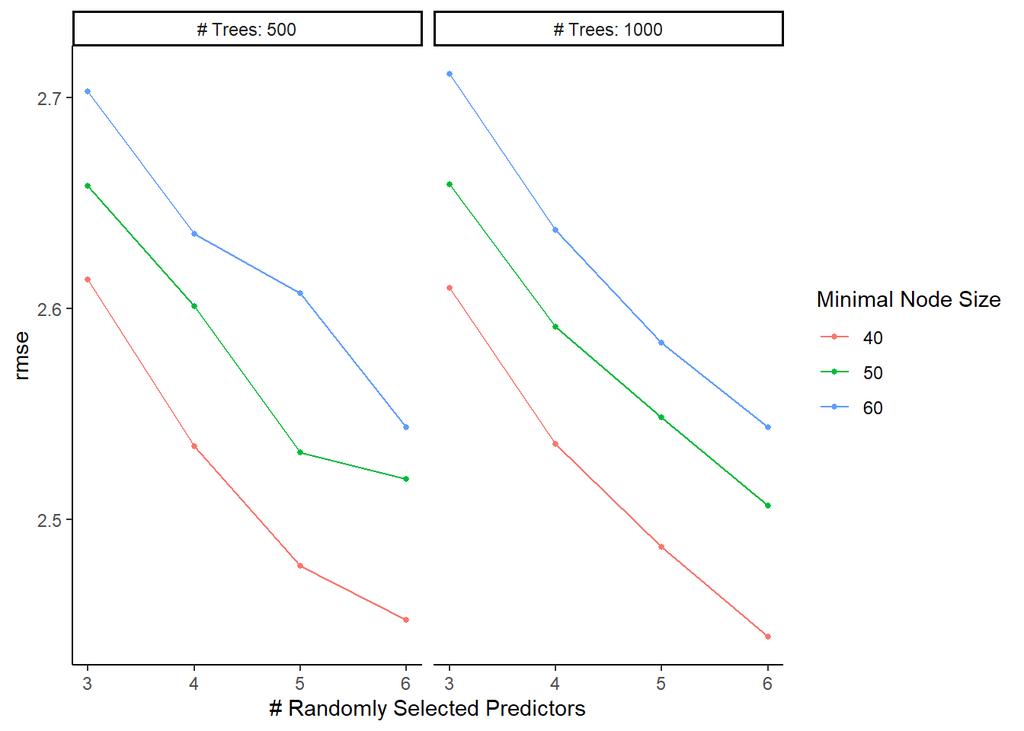

```r
#default visualization
RF_auto_plot <- RF_res %>% autoplot()
RF_auto_plot
```

```r
#save file
RF_auto_fig_file = here("results","RF-auto-plot-outlier.png")
ggsave(filename = RF_auto_fig_file, plot = RF_auto_plot)
```

### 5. Identify Best Model

```r
#select the RF model with the lowest rmse
RF_lowest_rmse <- RF_res %>%
                      tune::select_best("rmse")

#finalize the workflow by using the selected RF model
best_RF_wflow <- RF_wflow %>%
                      tune::finalize_workflow(RF_lowest_rmse)
best_RF_wflow
```

```
## == Workflow ====================================================================
## Preprocessor: Recipe
## Model: rand_forest()
##
## -- Preprocessor ----------------------------------------------------------------
## 2 Recipe Steps
##
## * step_unknown()
## * step_dummy()
##
## -- Model -----------------------------------------------------------------------
## Random Forest Model Specification (regression)
##
## Main Arguments:
##   mtry = 6
##   trees = 1000
##   min_n = 40
##
## Engine-Specific Arguments:
##   importance = permutation
##
## Computational engine: ranger
```

```r
#one last fit on the training data
best_RF_fit <- best_RF_wflow %>%
                    parsnip::fit(data = req_train_data)
```

### 6. Model evaluation

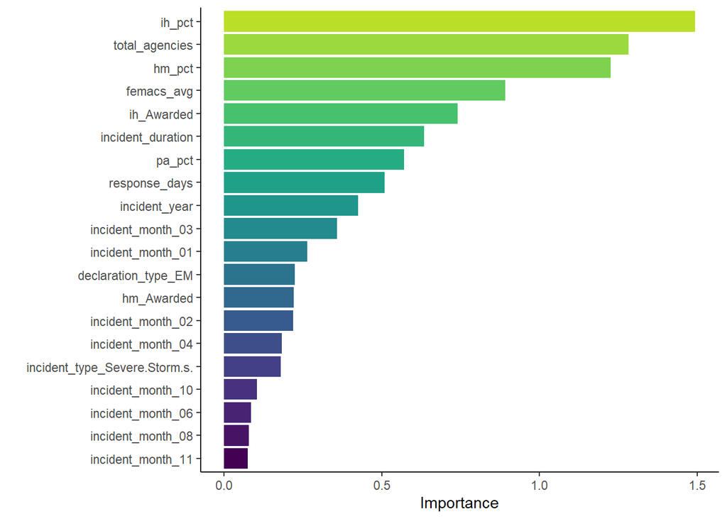

```r
#extract model from final fit
x_RF <- best_RF_fit$fit$fit$fit

#plot most important predictors in the model
RF_plot <- vip::vip(x_RF,
                    num_features = 20,
                    aesthetics = list(fill = viridis::viridis(20, option = "D", begin = 0.9, end = 0)))
RF_plot
```

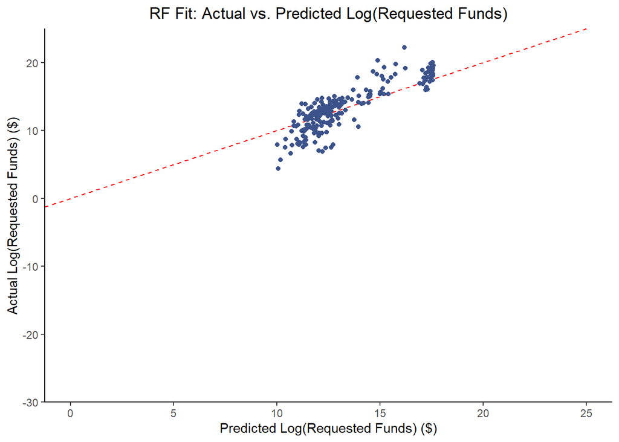

```r
#save manually as "RF-plot-outlier.png" -- ggsave throws errors

#find predictions and intervals
RF_resid <- best_RF_fit %>%
                broom.mixed::augment(new_data = req_train_data) %>%
                dplyr::select(.pred, log_req_amt) %>%
                dplyr::mutate(.resid = .pred - log_req_amt)

#plot model predictions from tuned model versus actual outcomes
#geom_abline is a 45 degree line, along which the results should fall
RF_pred_act <- ggplot2::ggplot(RF_resid, aes(x = .pred, y = log_req_amt)) +
                        geom_abline(slope = 1, intercept = 0, color = "red", lty = 2) +
                        geom_point(color = "#3b528b") +
                        scale_y_continuous(expand = c(0,0),
                                           limits = c(-30, 25)) +
                        scale_x_continuous(limits = c(0, 25)) +
                        labs(title = "RF Fit: Actual vs. Predicted Log(Requested Funds)",
                              x = "Predicted Log(Requested Funds) ($)",
                              y = "Actual Log(Requested Funds) ($)")
RF_pred_act
```

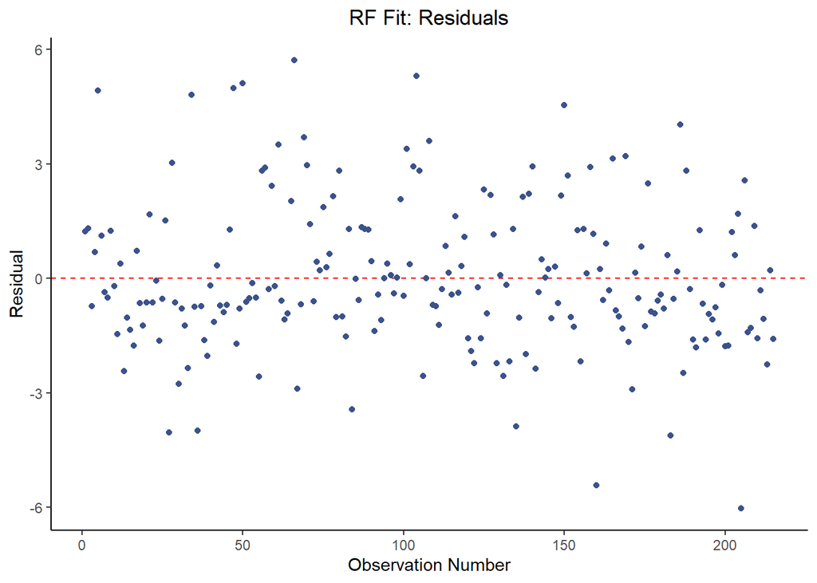

```r
#save file
RF_pred_act_file = here("results","RF-pred-act-outlier.png")
ggsave(filename = RF_pred_act_file, plot = RF_pred_act)
#plot model with residuals
#the geom_hline plots a straight horizontal line along which the results should fall
RF_resids <- ggplot2::ggplot(RF_resid, aes(x = as.numeric(row.names(RF_resid)), y = .resid))+
                            geom_hline(yintercept = 0, color = "red", lty = 2) +
                            geom_point(color = "#3b528b") +
                            labs(title = "RF Fit: Residuals",
                                  x = "Observation Number",
                                  y = "Residual")
RF_resids
```

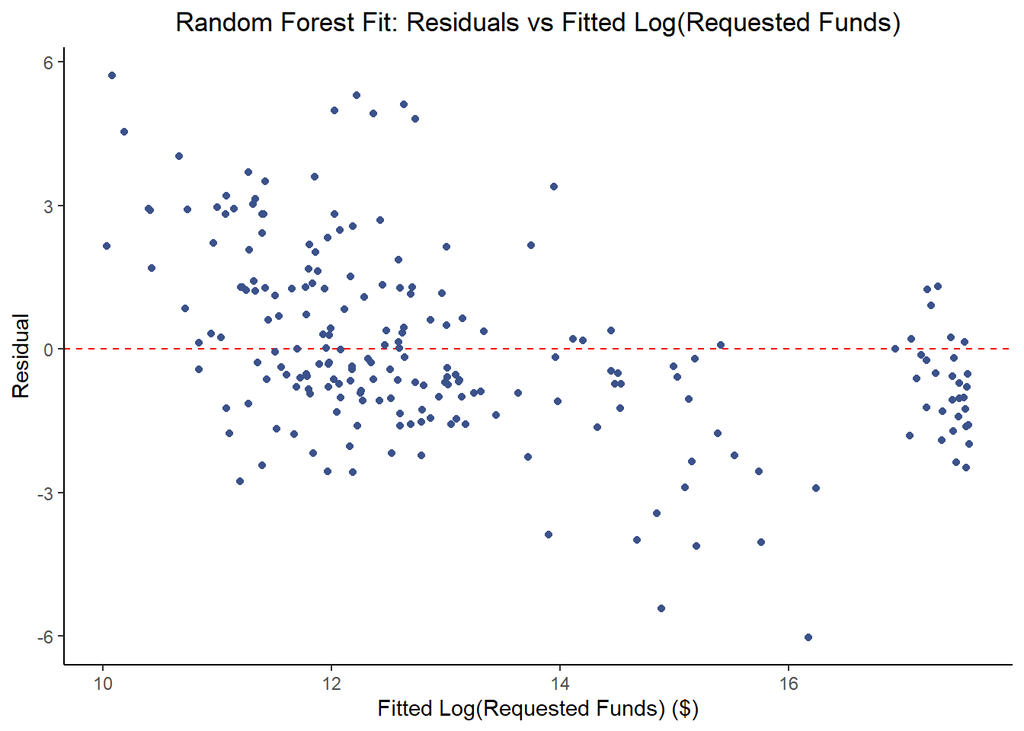

```r
#save file
RF_resid_file = here("results","RF-resid-outlier.png")
ggsave(filename = RF_resid_file, plot = RF_resids)
#plot model fit vs residuals
#the geom_hline plots a straight horizontal line along which the results fall
RF_pred_resid <- ggplot2::ggplot(RF_resid, aes(x = .pred, y = .resid))+
                          geom_hline(yintercept = 0, color = "red", lty = 2) +
                          geom_point(color = "#3b528b") +
                          labs(title = "Random Forest Fit: Residuals vs Fitted Log(Requested Funds)",
                                x = "Fitted Log(Requested Funds) ($)",
                                y = "Residual")
RF_pred_resid
```

```r
#save file
RF_pred_resid_file = here("results","RF-pred-resid-outlier.png")
ggsave(filename = RF_pred_resid_file, plot = RF_pred_resid)
#print the 10 best performing hyperparameter sets
RF_res %>%
  tune::show_best(n = 10) %>%
  dplyr::select(rmse = mean, std_err)
```

```
## # A tibble: 10 x 2
##     rmse std_err
##    <dbl>   <dbl>
##  1  2.44   0.212
##  2  2.45   0.215
##  3  2.48   0.211
##  4  2.49   0.218
##  5  2.51   0.215
##  6  2.52   0.221
##  7  2.53   0.222
##  8  2.53   0.225
##  9  2.54   0.222
## 10  2.54   0.221
```

```r
#print the best model
RF_performance <- RF_res %>% tune::show_best(n = 1)
RF_performance
```

```
## # A tibble: 1 x 9
##    mtry trees min_n .metric .estimator  mean     n std_err .config
##   <dbl> <dbl> <dbl> <chr>   <chr>      <dbl> <int>   <dbl> <chr>
## 1     6  1000    40 rmse    standard    2.44     5   0.212 Preprocessor1_Model16
```

```r
#compare model performance to null model (and other models)
RF_RMSE <- RF_res %>%
              tune::show_best(n = 1) %>%
              dplyr::transmute(
                rmse = round(mean, 3),
                SE = round(std_err, 4),
                model = "RF") %>%
             dplyr::bind_rows(tree_RMSE)
RF_RMSE
```

```
## # A tibble: 3 x 3
##    rmse    SE model
##   <dbl> <dbl> <chr>
## 1  2.44 0.212 RF
## 2  2.52 0.099 Tree
## 3  3.41 0     Null - Train
```

In examining the results of the RF model within the context of RMSE, it performs marginally better than the decision tree. It identifies percent of counties awarded IH program, total number of federal agencies involved, percent of counties awarded HM program, average FEMA cost share, and whether or not the IH program was awarded to any county in the state as the five most important predictors. Let’s try another model to see if we can find an improvement in the RMSE.

## Elastic Net Model

### 1. Model Specification

```r
#run parallels to determine number of cores
cores <- parallel::detectCores() - 1
cores
```

```
## [1] 19
```

```r
cl <- makeCluster(cores)

registerDoParallel(cl)

#define the elastic net model
elastic_mod <- linear_reg(mode = "regression",
                           penalty = tune(),
                           mixture = tune()) %>%
                parsnip::set_engine("glmnet")
```

### 2. Workflow Definition

```r
#define elastic net workflow
elastic_wflow <- workflows::workflow() %>%
                 workflows::add_model(elastic_mod) %>%
                 workflows::add_recipe(RA_rec)
```

### 3. Tuning Grid Specification

```r
#tuning grid specification
EN_grid <- dials::grid_regular(penalty(),
                               mixture(),
                               levels = 50)
```

### 4. Tuning Using Cross-Validation and the `tune_grid()` function

```r
#tune the model with previously specified cross-validation and RMSE as target metric
EN_res <- elastic_wflow %>%
              tune::tune_grid(resamples = req_folds_spatial,
                              grid = EN_grid,
                              control = control_grid(verbose = TRUE, save_pred = TRUE),
                              metrics = metric_set(rmse))

#look at top 5 EN models
top_EN_models <- EN_res %>%
                    tune::show_best("rmse", n = 5)
top_EN_models
```

```
## # A tibble: 5 x 8
##   penalty mixture .metric .estimator  mean     n std_err .config
##     <dbl>   <dbl> <chr>   <chr>      <dbl> <int>   <dbl> <chr>
## 1   0.153   0.918 rmse    standard    2.58     5   0.329 Preprocessor1_Model2296
## 2   0.153   0.939 rmse    standard    2.59     5   0.327 Preprocessor1_Model2346
## 3   0.153   0.898 rmse    standard    2.59     5   0.332 Preprocessor1_Model2246
## 4   0.153   0.878 rmse    standard    2.59     5   0.335 Preprocessor1_Model2196
## 5   0.153   0.959 rmse    standard    2.59     5   0.327 Preprocessor1_Model2396
```

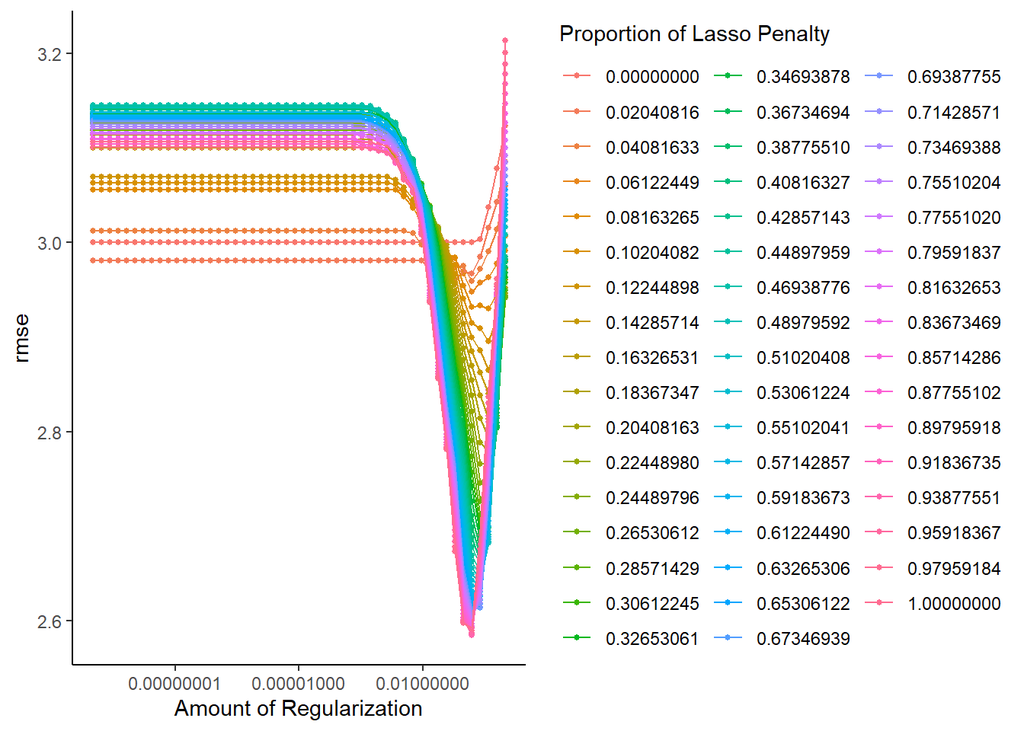

```r
#default visualization
EN_auto_plot <- EN_res %>% autoplot()
EN_auto_plot
```

```r
#save file
EN_auto_fig_file = here("results","EN-auto-plot-outlier.png")
ggsave(filename = EN_auto_fig_file, plot = EN_auto_plot)
```

### 5. Identify Best Model

```r
#select the EN model with the lowest rmse
EN_lowest_rmse <- EN_res %>%
                      tune::select_best("rmse")

#finalize the workflow by using the selected RF model
best_EN_wflow <- elastic_wflow %>%
                      tune::finalize_workflow(EN_lowest_rmse)
best_EN_wflow
```

```
## == Workflow ====================================================================
## Preprocessor: Recipe
## Model: linear_reg()
##
## -- Preprocessor ----------------------------------------------------------------
## 2 Recipe Steps
##
## * step_unknown()
## * step_dummy()
##
## -- Model -----------------------------------------------------------------------
## Linear Regression Model Specification (regression)
##
## Main Arguments:
##   penalty = 0.152641796717524
##   mixture = 0.918367346938775
##
## Computational engine: glmnet
```

```r
#one last fit on the training data
best_EN_fit <- best_EN_wflow %>%
                    parsnip::fit(data = req_train_data)
```

### 6. Model evaluation

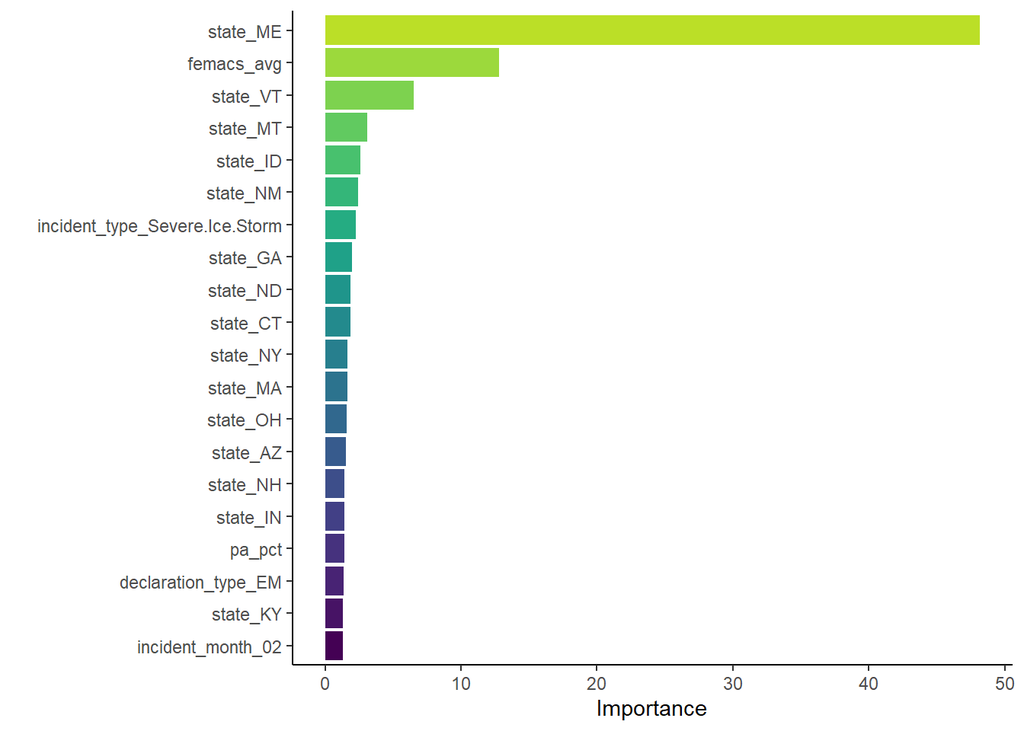

```r
#extract model from final fit
x_EN <- best_EN_fit$fit$fit$fit

#plot most important predictors in the model
EN_plot <- vip::vip(x_EN,
                    num_features = 20,
                    aesthetics = list(fill = viridis::viridis(20, option = "D", begin = 0.9, end = 0)))
EN_plot
```

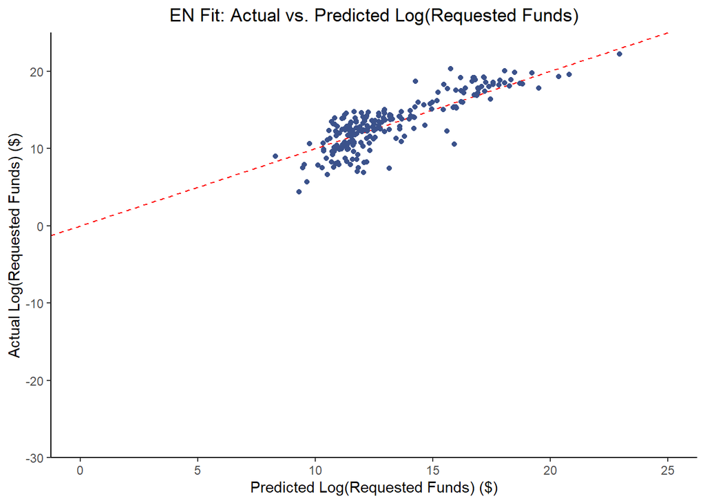

```r
#save manually as "EN-plot-outlier.png" -- ggsave throws errors

#find predictions and intervals
EN_resid <- best_EN_fit %>%
                broom.mixed::augment(new_data = req_train_data) %>%
                dplyr::select(.pred, log_req_amt) %>%
                dplyr::mutate(.resid = .pred - log_req_amt)

#plot model predictions from tuned model versus actual outcomes
#geom_abline is a 45 degree line, along which the results should fall
EN_pred_act <- ggplot2::ggplot(EN_resid, aes(x = .pred, y = log_req_amt)) +
                        geom_abline(slope = 1, intercept = 0, color = "red", lty = 2) +
                        geom_point(color = "#3b528b") +
                        scale_y_continuous(expand = c(0,0),
                                           limits = c(-30, 25)) +
                        scale_x_continuous(limits = c(0, 25)) +
                        labs(title = "EN Fit: Actual vs. Predicted Log(Requested Funds)",
                              x = "Predicted Log(Requested Funds) ($)",
                              y = "Actual Log(Requested Funds) ($)")
EN_pred_act
```